# SWE & Snow Depth

### This rmarkdown shows some of the relationships between SWE and snow depth at each location. Analyses conducted include:

- Correlation between SWE and Snow Depth with the colors grouped by months
- linear relationship between Swe and snow depth for each month
- graph of the slopes of the monthly linear relationship

## General Patterns

#### Correlation between SWE and Snow Depth (November - April Water Year)

- SWE and snow depth are highly correlated across regions (>0.9)
- Generally, as snow depth and swe values get larger, they become less closely correlated

#### Monthly linear relationships between SWE and Snow Depth

- SWE is a function of depth and density, so SWE/depth = bulk density
- So through the water year, we see generally increasing density at all locations November to March.
  - However, in April, there is sometimes a drop in density depending on location - this may simply be because most of the snow has melted

```r
calc_swe_metrics(car_swe_dpth, "year", max)
```

```
## # A tibble: 17 x 3
##    date       swe_mm waterYear
##    <date>      <dbl>     <dbl>
##  1 2003-01-01   0         2004
##  2 2004-01-01   7.28      2004
##  3 2005-01-01   3.64      2005
##  4 2006-01-01  12.2       2006
##  5 2007-01-01  15.7       2007
##  6 2008-01-01  45.8       2008
##  7 2009-01-01  39.8       2009
##  8 2010-01-01  92.1       2010
##  9 2011-01-01  29.3       2011
## 10 2012-01-01  40.2       2012
## 11 2013-01-01  44.3       2013
## 12 2014-01-01  14.7       2014
## 13 2015-01-01  46.3       2015
## 14 2016-01-01  73.4       2016
## 15 2017-01-01  64.3       2017
## 16 2018-01-01   6.82      2018
## 17 2019-01-01  70.1       2019
```

### Carrizo

- Generally, January, February, and March swe and depth values are less correlated than other months

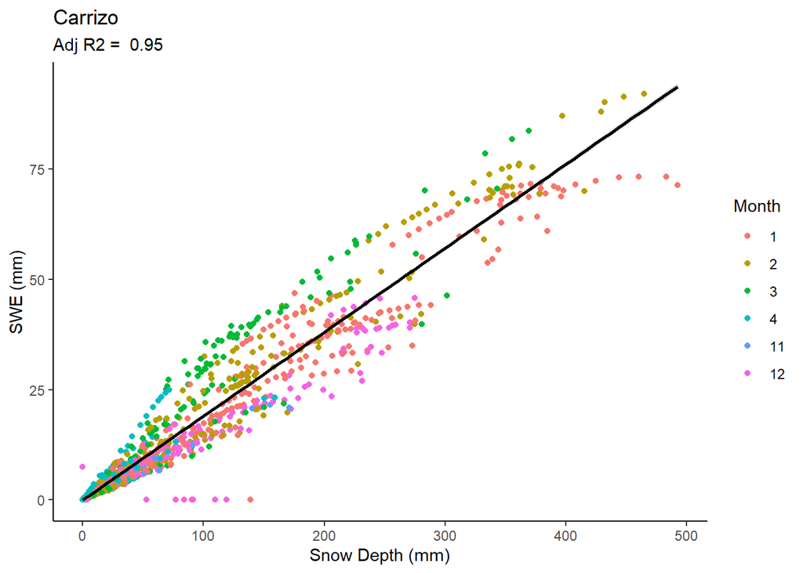

Each month has it’s own line:

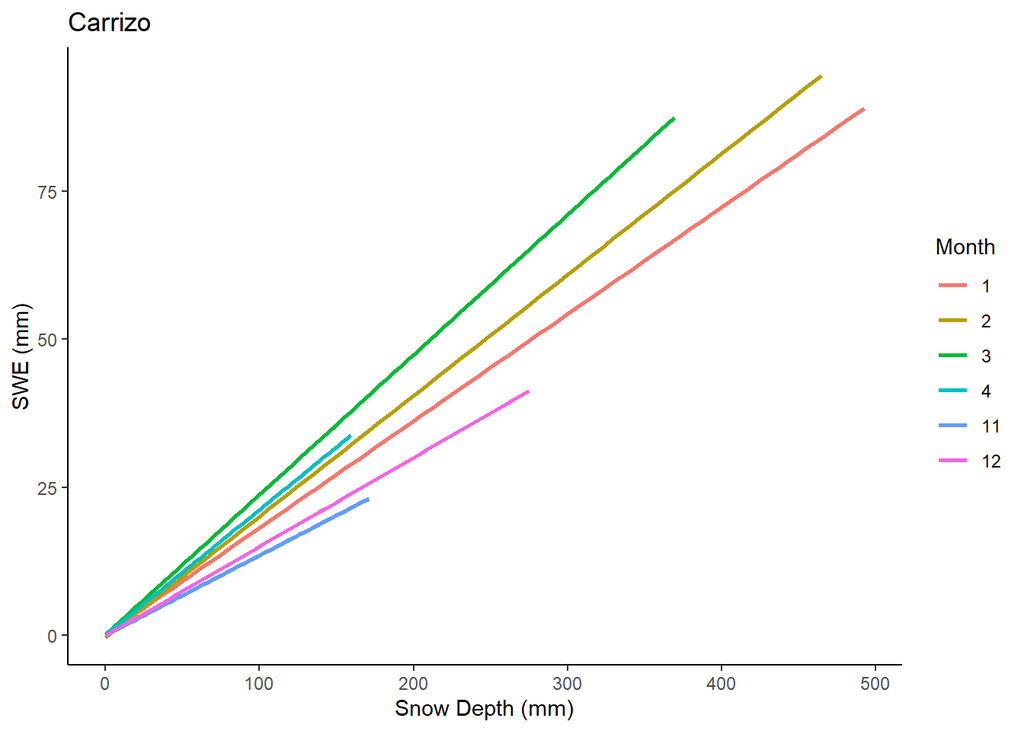

Slope of the line of the linear relationship of each month’s swe and snow depth - almost linearly increasing slop through the water year until April, where the slope decreases back down to almost the February slope

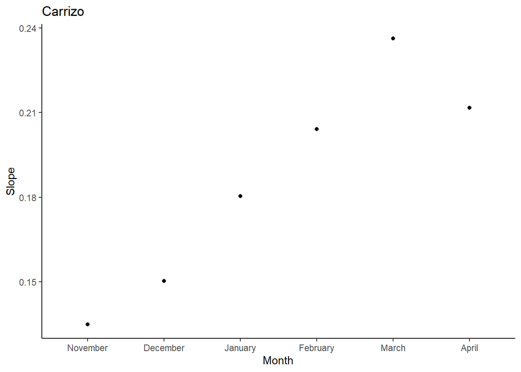

## Chuska

- Generally, January, February, March, amd some April swe and depth values are less correlated than other months

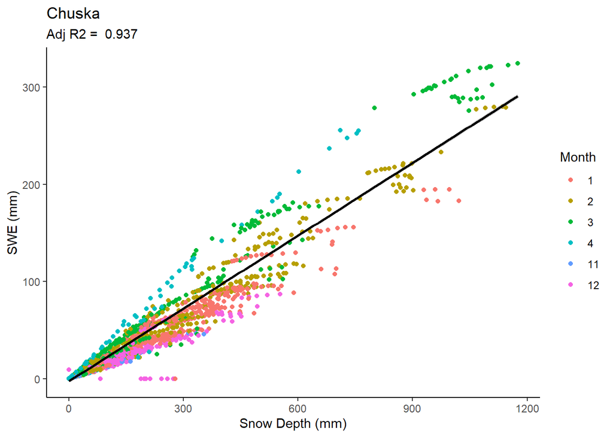

Each month has it’s own line:

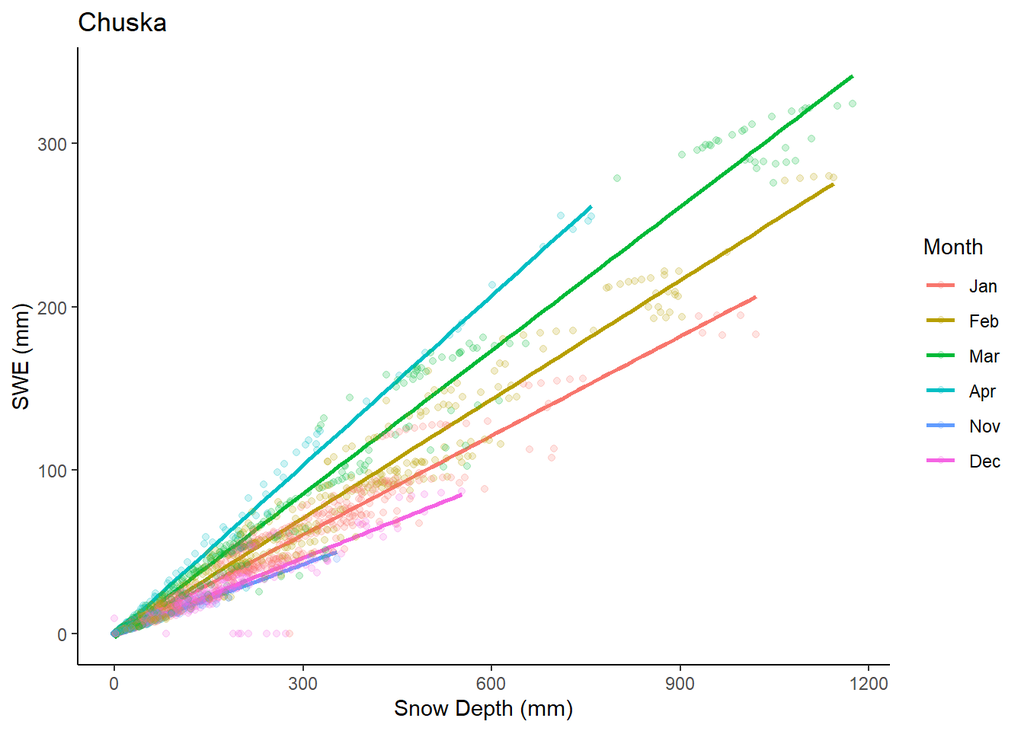

- almost perfect linear increase in the slope of the relationship between swe and depth through time

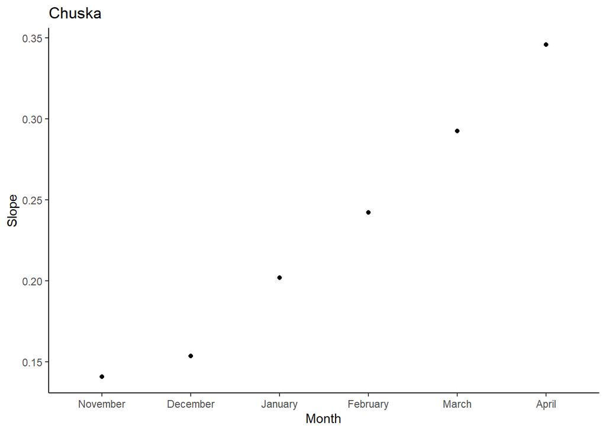

## Black Mesa

- Generally, January, February, and March swe and depth values are less correlated than other months

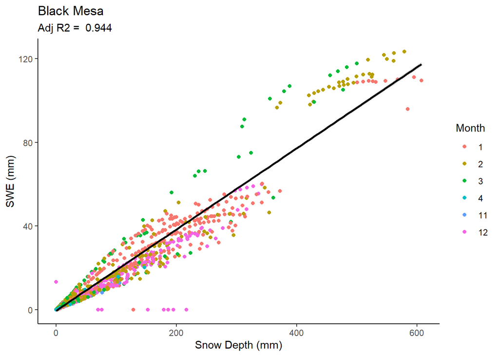

Each month has it’s own line:

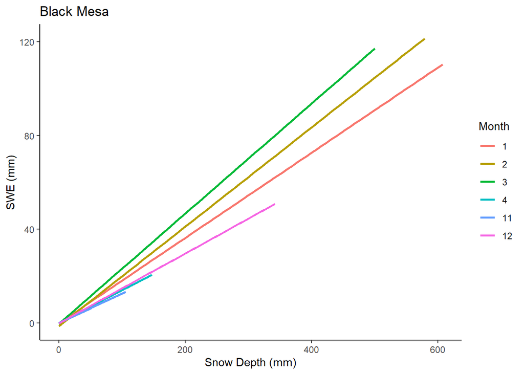

- almost linearly increasing slop through the water year until April, where the slope decreases back down to almost the November slope

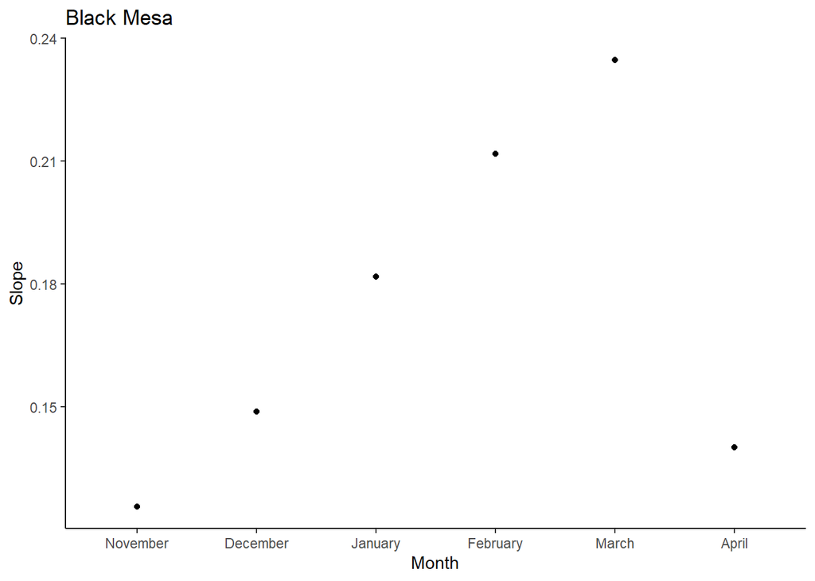

## Navajo Mt

- March, January, and some december most often less correlated

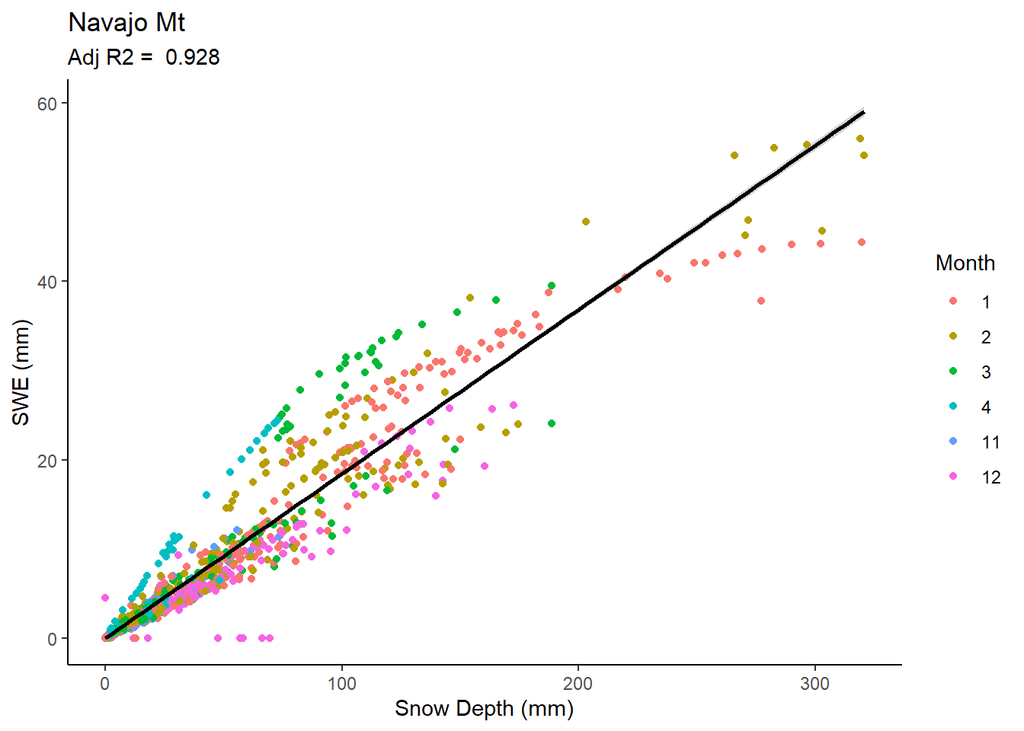

Each month has it’s own line:

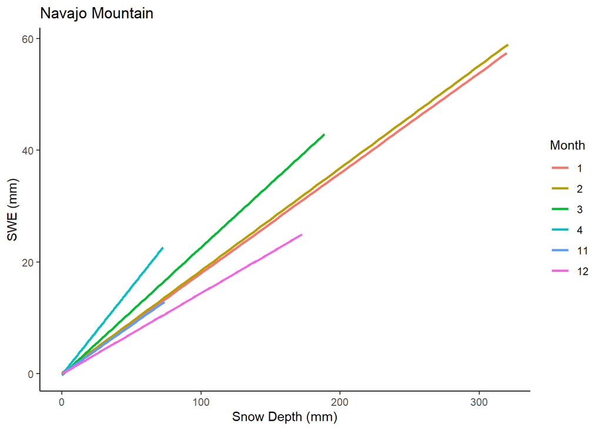

- Seems to be the only location where there is not really a clear linear increase in the slope of the relationship between swe and snow depth

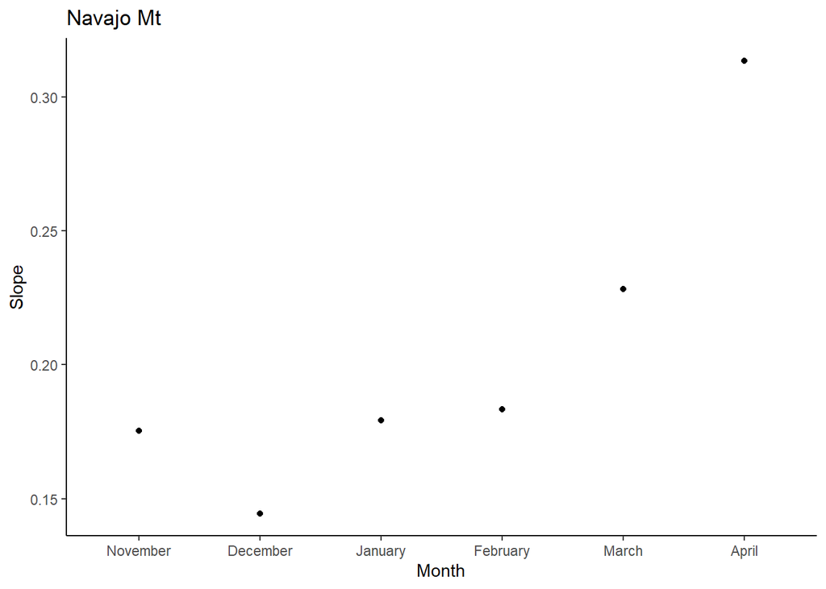

## Mt Powell

- Jn, Feb and March seem to be outliers

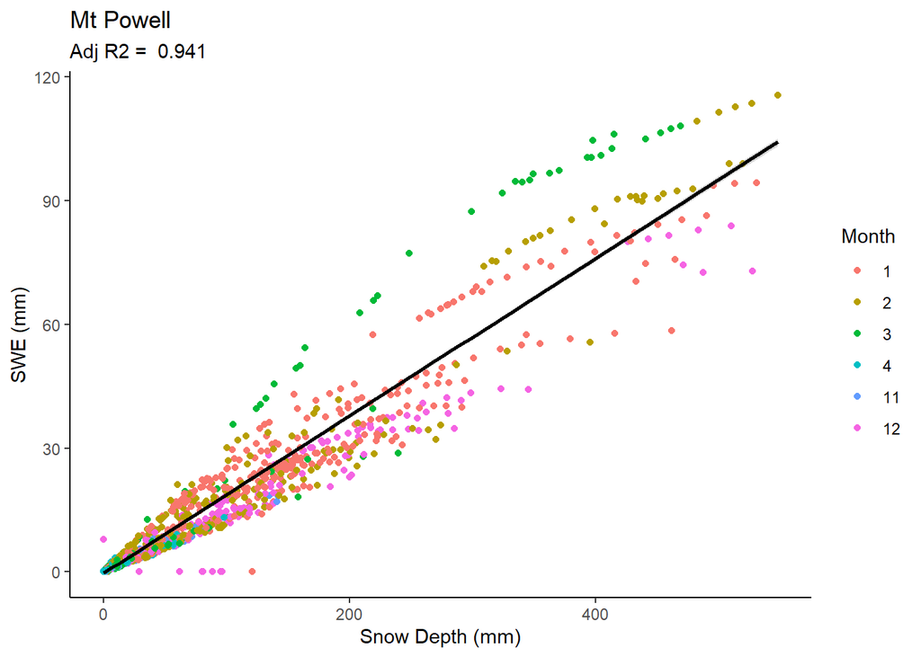

Each month has it’s own line:

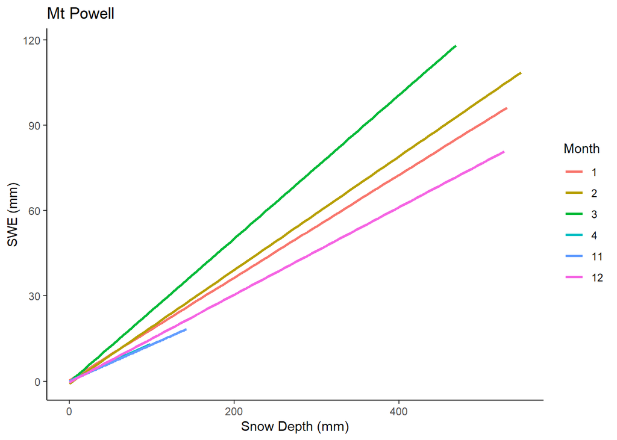

- almost linearly increasing slop through the water year until April, where the slope decreases back down to almost the November slope

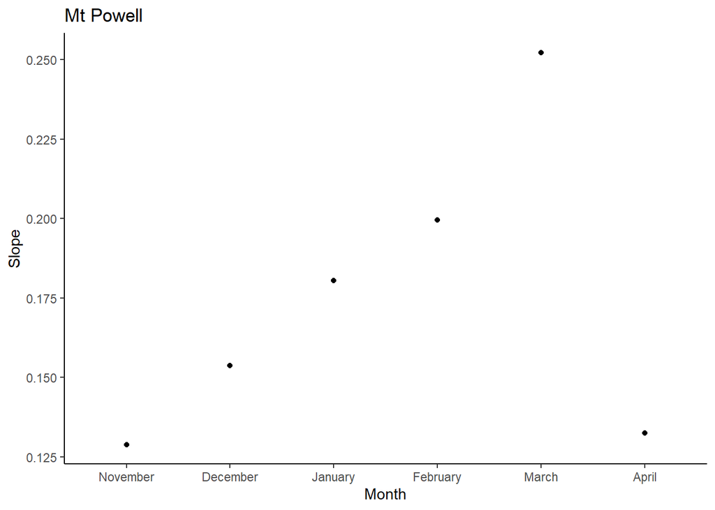

## Defiance Plateau

- March seems to be least correlated

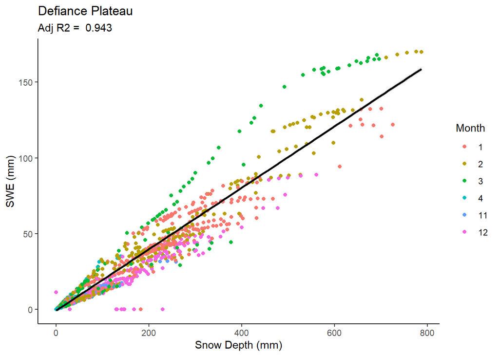

Each month has it’s own line:

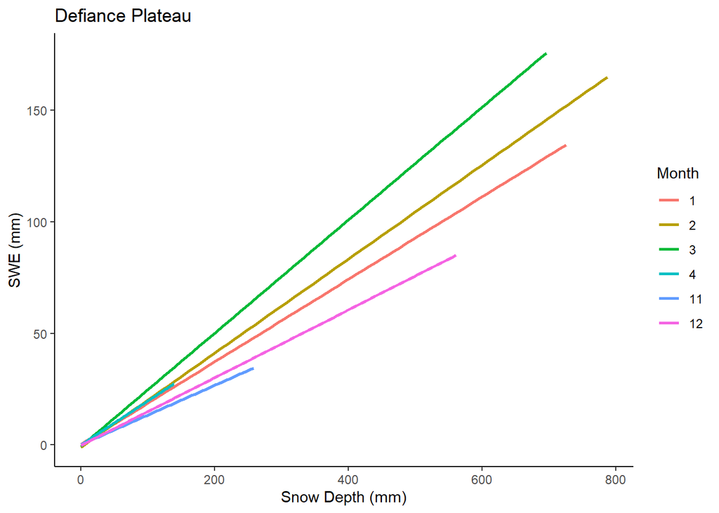

- almost linearly increasing slop through the water year until April, where the slope decreases back down to almost the January slope

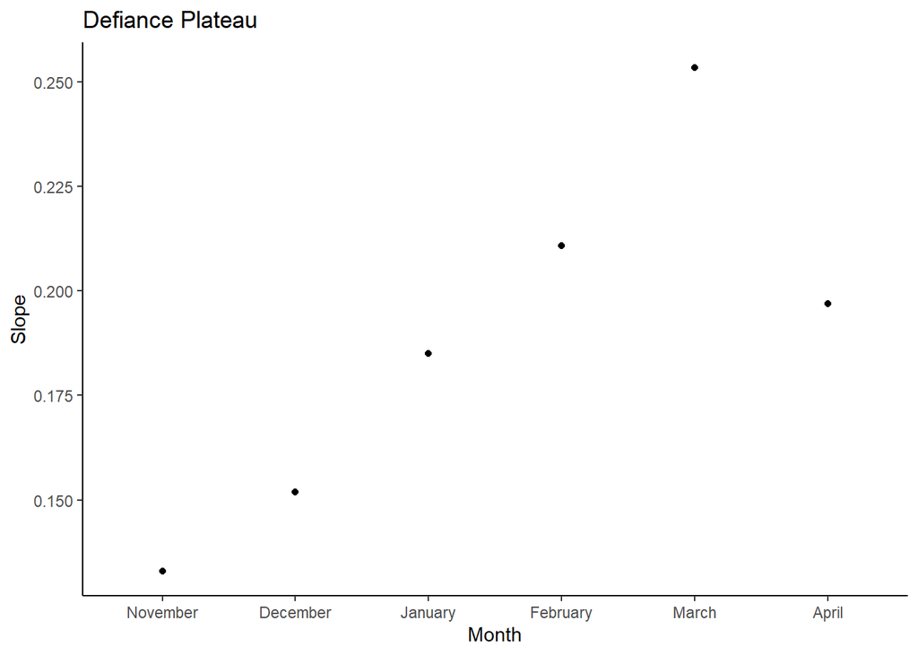

## SWE-depth ratio

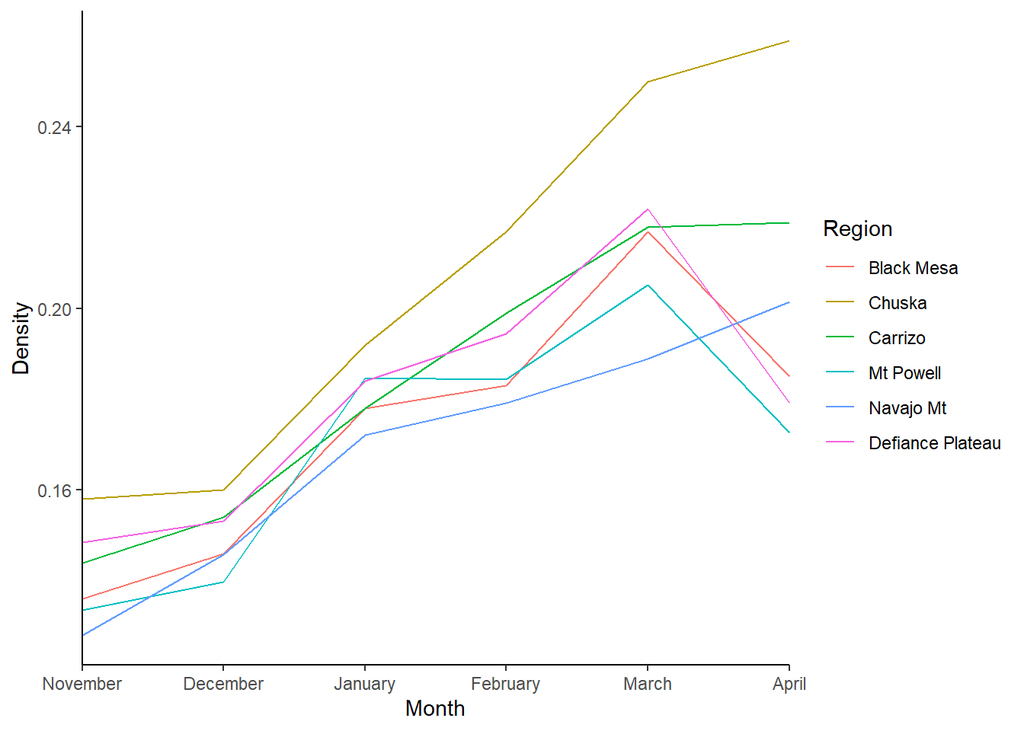

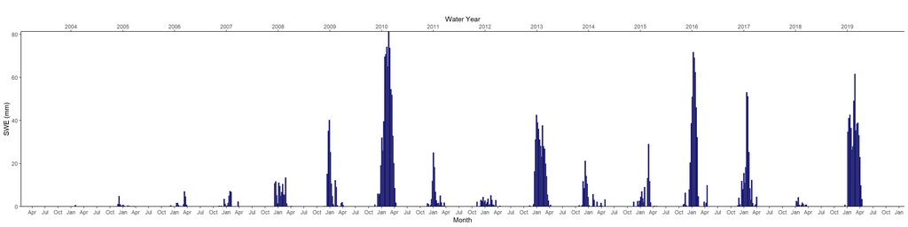

```r
car_wk_mean_swe <- calc_swe_metrics(car_swe_dpth, "week", mean)
ch_wk_mean_swe <- calc_swe_metrics(ch_swe_dpth, "week", mean)
nm_wk_mean_swe <- calc_swe_metrics(nm_swe_dpth, "week", mean)
mp_wk_mean_swe <- calc_swe_metrics(mp_swe_dpth, "week", mean)
dp_wk_mean_swe <- calc_swe_metrics(dp_swe_dpth, "week", mean)
bm_wk_mean_swe <- calc_swe_metrics(bm_swe_dpth, "week", mean)

graph_with_wateryear(car_wk_mean_swe, type = geom_col,  variable = "swe_mm", ylab = "SWE (mm)")
```

### SWE and Snow depth (November - April Water Year)

- Generally, snow depth is much greater than SWE, but follows the same general patter

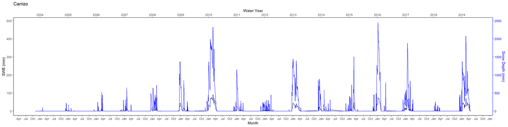

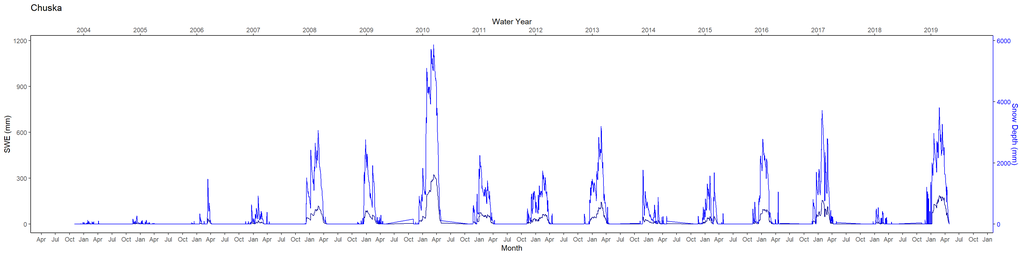

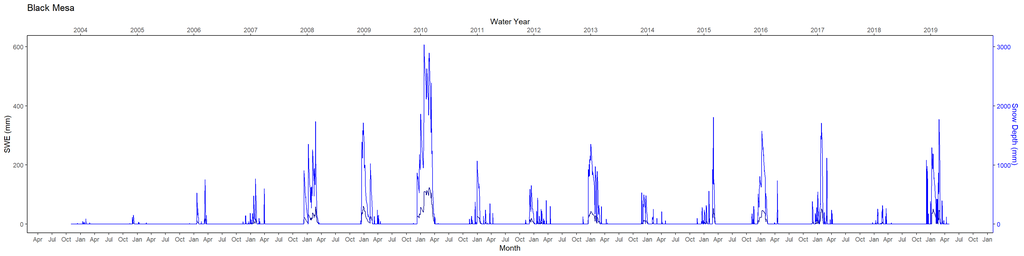

### Chuska SWE vs depth monthly anomaly

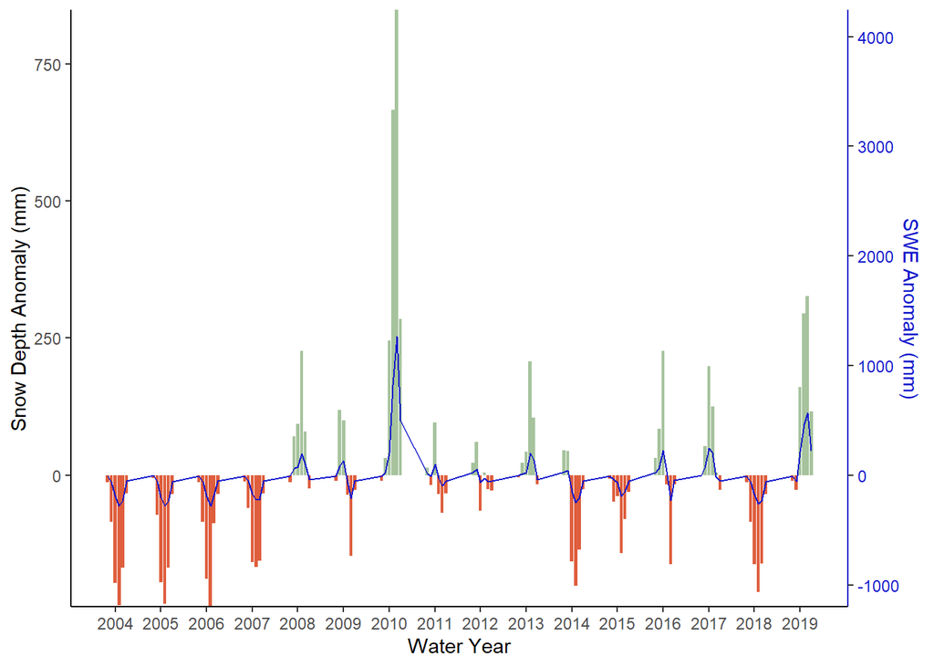

### Depth scaled (depth*0.2) by swe/depth metric

- shows how well correlated SWE and snow depth are

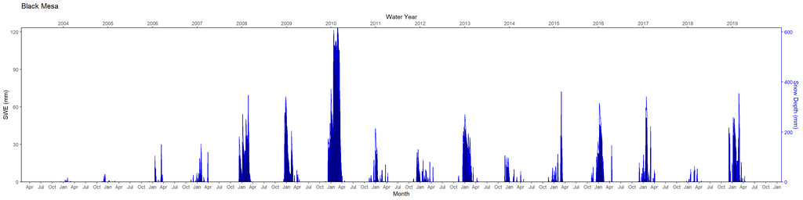